# DESCRIPTIVE STATISTICS

```python
import pandas as pd
import numpy as np
```

```python
df = pd.read_csv('D:\WORKSPACE\PYTHON\Project\House Price\FinalData.csv')
```

```python
df.head()
```

|  | Unnamed: 0.1 | Unnamed: 0 | Property_type | Size | Number_of_bedrooms | Number_of_bathrooms | Furniture | Number_of_floors | Main_direction | Property_featured | Street | Ward | District | City | Price | Distance |
| --- | --- | --- | --- | --- | --- | --- | --- | --- | --- | --- | --- | --- | --- | --- | --- | --- |
| 0 | 0 | 0 | Nhà ngõ, hẻm | 200.0 | 3 | 2 | Nội thất cao cấp | 2.0 | NaN | NaN | Trần Cao Vân | Phường Xuân Hà | Quận Thanh Khê | Đà Nẵng | 5.40 | 4.003544 |
| 1 | 1 | 1 | Nhà ngõ, hẻm | 62.0 | 3 | 3 | NaN | 2.0 | Tây Bắc | NaN | Trần Cao Vân | Phường Xuân Hà | Quận Thanh Khê | Đà Nẵng | 3.39 | 4.003544 |
| 2 | 2 | 2 | Nhà ngõ, hẻm | 50.5 | 3 | 3 | NaN | 3.0 | Nam | NaN | Trần Cao Vân | Phường Xuân Hà | Quận Thanh Khê | Đà Nẵng | 3.75 | 4.003544 |
| 3 | 3 | 3 | Nhà ngõ, hẻm | 51.0 | 3 | 3 | NaN | 3.0 | Nam | NaN | Trần Cao Vân | Phường Xuân Hà | Quận Thanh Khê | Đà Nẵng | 3.75 | 4.003544 |
| 4 | 4 | 4 | Nhà ngõ, hẻm | 60.0 | 3 | 2 | NaN | 2.0 | NaN | NaN | Trần Cao Vân | Phường Xuân Hà | Quận Thanh Khê | Đà Nẵng | 3.10 | 4.003544 |

```python
df.info()
```

```
<class 'pandas.core.frame.DataFrame'>
RangeIndex: 2376 entries, 0 to 2375
Data columns (total 16 columns):
 #   Column               Non-Null Count  Dtype
---  ------               --------------  -----
 0   Unnamed: 0.1         2376 non-null   int64
 1   Unnamed: 0           2376 non-null   int64
 2   Property_type        2319 non-null   object
 3   Size                 2376 non-null   float64
 4   Number_of_bedrooms   2376 non-null   object
 5   Number_of_bathrooms  1916 non-null   object
 6   Furniture            535 non-null    object
 7   Number_of_floors     1718 non-null   float64
 8   Main_direction       1191 non-null   object
 9   Property_featured    88 non-null     object
 10  Street               2376 non-null   object
 11  Ward                 2376 non-null   object
 12  District             2376 non-null   object
 13  City                 2376 non-null   object
 14  Price                2376 non-null   float64
 15  Distance             2376 non-null   float64
dtypes: float64(4), int64(2), object(10)
memory usage: 297.1+ KB
```

```python
df.drop(columns=['Unnamed: 0.1', 'Unnamed: 0'], inplace=True)
```

```python
# Kiểm tra số giá trị Null ở các thuộc tính:
feature_cols = df.columns
def display_null(df, feature_cols):
    n_rows = df.shape[0]
    for col in feature_cols:
        null_count = df[col].isnull().sum()
        if null_count > 0:
            print(f"{col} has {null_count*100/n_rows:.2f}% null values.")

display_null(df, feature_cols)
```

```
Property_type has 2.40% null values.
Number_of_bathrooms has 19.36% null values.
Furniture has 77.48% null values.
Number_of_floors has 27.69% null values.
Main_direction has 49.87% null values.
Property_featured has 96.30% null values.
```

```python
df['Furniture'] = df['Furniture'].fillna('Unknown')
df['Main_direction'] = df['Main_direction'].fillna('Unknown')
```

Cột [Property_features] có giá trị null lớn. Vậy ta loại bỏ thuộc tính này khỏi DataFrame.

Và cột city chỉ có 1 giá trị Đà Nẵng không ảnh hưởng đến tổng thể data nên ta cũng loại bỏ thuộc tính này khỏi DataFrame.

```python
df.drop(columns=['Property_featured'], inplace=True)
df.drop(columns=['City'], inplace=True)
```

```python
df.describe()
```

|  | Size | Number_of_floors | Price | Distance |
| --- | --- | --- | --- | --- |
| count | 2376.000000 | 1718.000000 | 2376.000000 | 2376.000000 |
| mean | 89.700951 | 2.615250 | 9.601331 | 4.808963 |
| std | 53.976872 | 1.616867 | 55.232208 | 2.605697 |
| min | 10.000000 | 1.000000 | 1.000000 | 0.292024 |
| 25% | 60.000000 | 2.000000 | 2.945000 | 2.623318 |
| 50% | 81.000000 | 3.000000 | 4.150000 | 4.535284 |
| 75% | 100.000000 | 3.000000 | 6.300000 | 6.480091 |
| max | 970.000000 | 35.000000 | 990.000000 | 17.082107 |

```python
df.describe(include="O")
```

|  | Property_type | Number_of_bedrooms | Number_of_bathrooms | Furniture | Main_direction | Street | Ward | District |
| --- | --- | --- | --- | --- | --- | --- | --- | --- |
| count | 2319 | 2376 | 1916 | 2376 | 2376 | 2376 | 2376 | 2376 |
| unique | 4 | 11 | 7 | 5 | 9 | 997 | 52 | 7 |
| top | Nhà mặt phố, mặt tiền | 3 | 2 | Unknown | Unknown | Trần Cao Vân | Phường Hòa Minh | Quận Hải Châu |
| freq | 1348 | 1109 | 619 | 1841 | 1185 | 75 | 254 | 495 |

# **I. Descriptive statistics**

```python
import matplotlib.pyplot as plt
import seaborn as sns
from matplotlib.colors import ListedColormap
```

```python
df1 = df.copy()
```

## **PRICE**

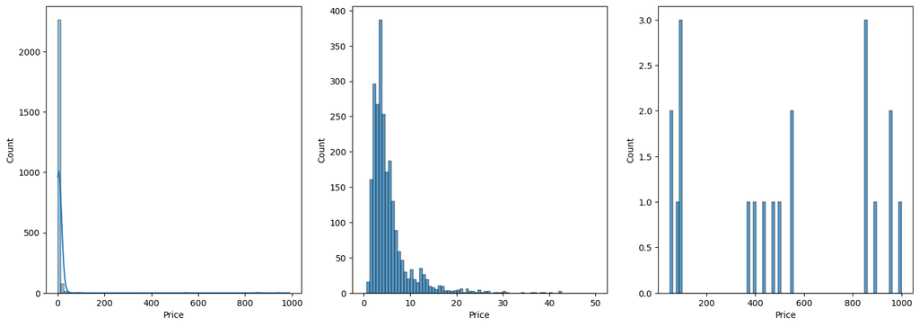

```python
fig, axes = plt.subplots(1,3, figsize=(18,6))

sns.histplot(df1, x='Price', kde=True, bins=75, ax=axes[0])
sns.histplot(df1, x='Price', bins=75, binrange=[0,50], ax=axes[1])
sns.histplot(df1, x='Price', bins=75, binrange=[50,1000], ax=axes[2])
```

- Giá trải dài trong khoản (0,1000) tỷ VND
- Giá thành tập trung chủ yếu ở khoảng dưới 10 tỷ VND
- Trong khoản (50,1000) tỷ ở biểu đồ 3 chỉ rải rác trong khoản (1,3) căn nhà và số lượng rất ít

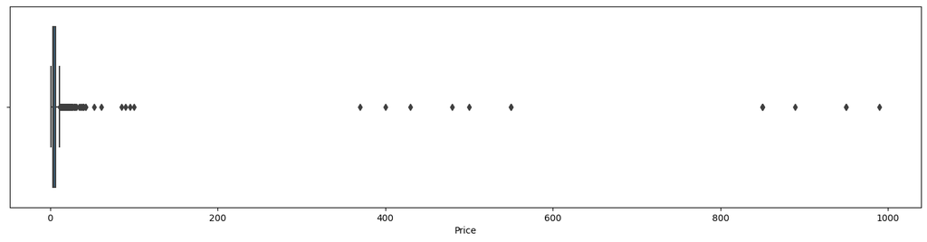

```python
plt.figure(figsize=(18,4))
sns.boxplot(df1, x='Price')
plt.show()
```

Có thể thấy có nhiều outlier trong thuộc tính này. Ta bắt đầu xử lý chúng với IQR

Xử lý giá trị outlier với IQR

```python
Q1 = np.percentile(df1['Price'],25)
Q3 = np.percentile(df1['Price'], 75)

IQR = Q3 - Q1

threshold_lower = Q1 - 1.5*IQR
threshold_upper = Q3 + 1.5*IQR

df1 = df1[(df1['Price'] >= threshold_lower) & (df1['Price'] <= threshold_upper)]
```

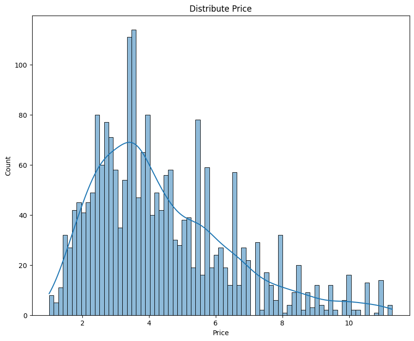

```python
plt.figure(figsize=(10,8))
sns.histplot(df1, x='Price', kde=True, bins=75)
plt.title("Distribute Price")
```

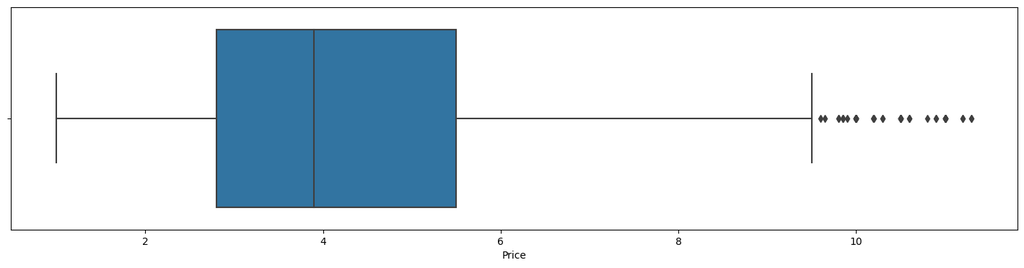

```python
plt.figure(figsize=(18,4))
sns.boxplot(df1, x='Price')
plt.show()
```

## **Property_Type**

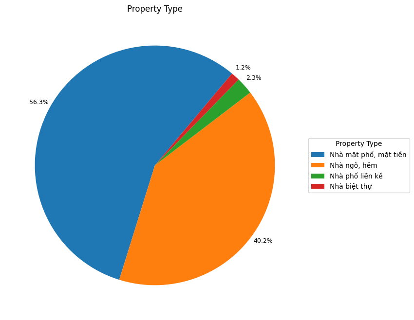

```python
group_count = df1['Property_type'].value_counts()

plt.figure(figsize=(8,8))

wedges, text, autotext = plt.pie(group_count, startangle=50, autopct=lambda pct: f"{pct:.1f}%", pctdistance=1.1)

plt.setp(autotext, size=9)

plt.title("Property Type")

plt.legend(wedges, group_count.index, title = "Property Type", loc = "center left", bbox_to_anchor = (1,0,0.5,1))

plt.show()
```

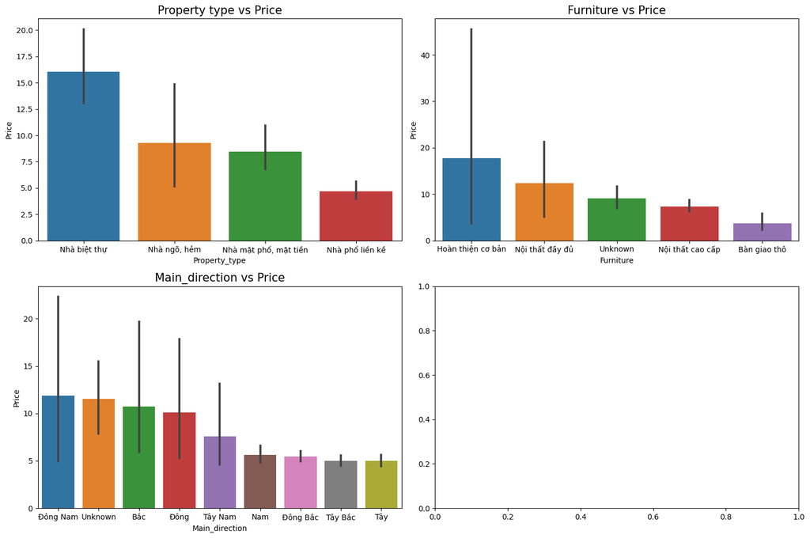

```python
fig, axes = plt.subplots(2,2, figsize=(15,10))


sns.barplot(data=df,
            x="Property_type",
            y="Price",
            order=df.groupby("Property_type")["Price"].mean().sort_values(ascending=False).index, ax=axes[0][0])

sns.barplot(data=df,
            x="Furniture",
            y="Price",
            order=df.groupby("Furniture")["Price"].mean().sort_values(ascending=False).index, ax=axes[0][1])

sns.barplot(data=df,
            x="Main_direction",
            y="Price",
            order=df.groupby("Main_direction")["Price"].mean().sort_values(ascending=False).index, ax=axes[1][0])

axes[0][0].set_title('Property type vs Price', fontsize=15)
axes[0][1].set_title('Furniture vs Price', fontsize=15)
axes[1][0].set_title('Main_direction vs Price', fontsize=15)

plt.tight_layout()
plt.show()
```

- Ở thuộc tính này các loại hình nhà ở chủ yếu là [Nhà mặt phố, mặt tiền] và [Nhà ngỏ hẻm]
- [Nhà phố liền kề] và [Nhà biệt thự] chiếm số lượng ít
- Trung bình tổng thể giá nhà theo loại tài sản dễ dàng dự đoán được như trên

## **SIZE**

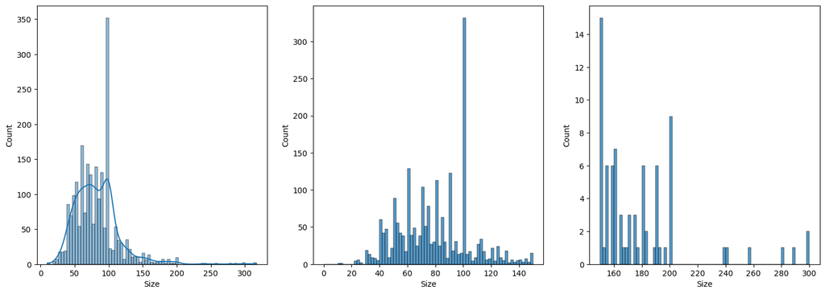

```python
fig, axes = plt.subplots(1,3, figsize=(18,6))

sns.histplot(df1, x='Size', kde=True, bins=75, ax=axes[0])
sns.histplot(df1, x='Size', bins=75, binrange=[0,150], ax=axes[1])
sns.histplot(df1, x='Size', bins=75, binrange=[150,300], ax=axes[2])
```

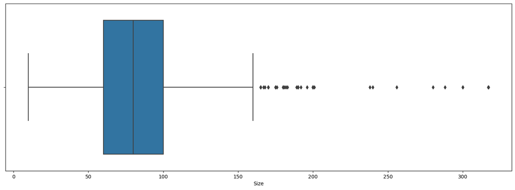

```python
plt.figure(figsize=(18, 6))
sns.boxplot(data=df1, x="Size")

plt.show()
```

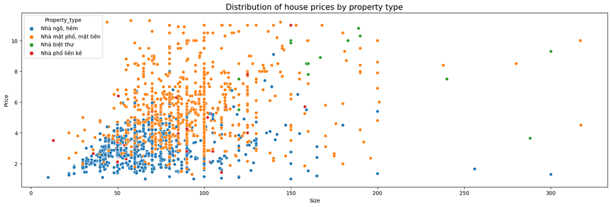

```python
fig, axes = plt.subplots(figsize=(20,6))

sns.scatterplot(data=df1, x="Size", y="Price", hue="Property_type")
plt.title("Distribution of house prices by property type", fontsize=15)
```

Không có gì ngạc nhiên khi tổng thể giá [Biệt thự] [Nhà mặt phố, mặt tiền] cao hơn các loại khác

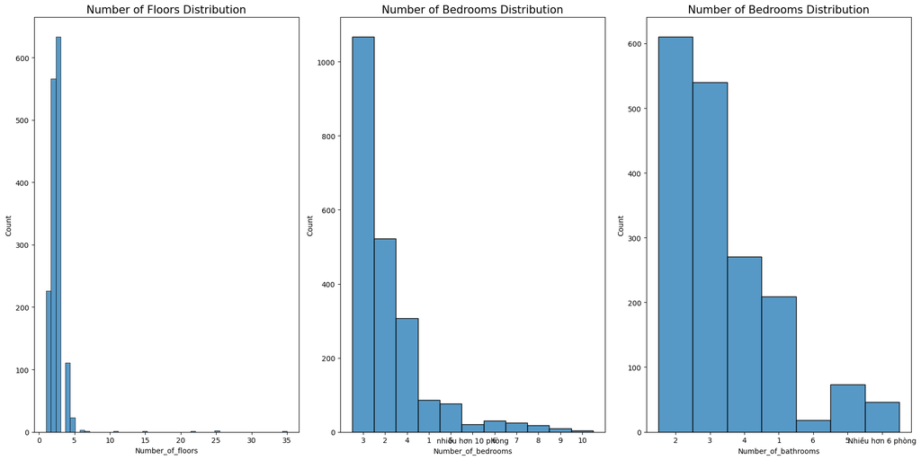

```python
fig, axes = plt.subplots(1, 3, figsize=(18, 9))

sns.histplot(data=df1, x="Number_of_floors", bins=50, ax=axes[0])
axes[0].set_title("Number of Floors Distribution", fontsize=15)

sns.histplot(data=df1, x="Number_of_bedrooms", bins=50, ax=axes[1])
axes[1].set_title("Number of Bedrooms Distribution", fontsize=15)

sns.histplot(data=df1, x="Number_of_bathrooms", bins=50, ax=axes[2])
axes[2].set_title("Number of Bedrooms Distribution", fontsize=15)

plt.tight_layout()
plt.show()
```

Số tầng tập trung chủ yếu từ 5 tấng trở lại và số lượng phòng ngủ và phòng tắm/vệ sinh tập trung từ 4 phòng trở lại

## **LOCATION**

```python
location = pd.read_csv("D:\WORKSPACE\PYTHON\Project\House Price\Distance.csv")
location.head()
```

|  | Unnamed: 0 | Street | Ward | District | Province | Address | Coordinates | Distance |
| --- | --- | --- | --- | --- | --- | --- | --- | --- |
| 0 | 0 | Trần Cao Vân | Phường Xuân Hà | Quận Thanh Khê | Đà Nẵng | Trần Cao Vân, Phường Xuân Hà, Quận Thanh Khê, ... | (16.0699467, 108.1847308) | 4.003544 |
| 1 | 1 | Trần Văn Dư | Phường Mỹ An | Quận Ngũ Hành Sơn | Đà Nẵng | Trần Văn Dư, Phường Mỹ An, Quận Ngũ Hành Sơn, ... | (16.0414912, 108.244925) | 4.591375 |
| 2 | 2 | phan bá vành | Phường Nại Hiên Đông | Quận Sơn Trà | Đà Nẵng | phan bá vành, Phường Nại Hiên Đông, Quận Sơn T... | (16.098652, 108.2304623) | 2.650554 |
| 3 | 3 | Tôn Thất Đạm | Phường Xuân Hà | Quận Thanh Khê | Đà Nẵng | Tôn Thất Đạm, Phường Xuân Hà, Quận Thanh Khê, ... | (16.0720982, 108.2012813) | 2.219723 |
| 4 | 4 | Đường Nguyễn Công Trứ | Phường Phước Mỹ | Quận Sơn Trà | Đà Nẵng | Đường Nguyễn Công Trứ, Phường Phước Mỹ, Quận S... | (16.0658149, 108.2389006) | 2.187388 |

```python
import folium
from folium.plugins import HeatMap

coordinates_list = []
for coord_str in location['Coordinates']:
    coord = coord_str.strip('()').split(',')
    coordinates_list.append((float(coord[0]), float(coord[1])))

m = folium.Map(location=[16.07729181528557, 108.22274899303063], zoom_start=14)

heat_map = HeatMap(coordinates_list)

m.add_child(heat_map)

m
```

Make this Notebook Trusted to load map: File -> Trust Notebook

[interactive chart not shown]

Các tài sản đang được rao bán nằm rải rác khắp trên địa bàn thành phố Đà Nẵng. Các điểm dự liệu tập trung nhiều ở những con đường chính của thành phố như

Điện Biên Phủ, Nguyễn Văn Linh, Ngũ Hành Sơn

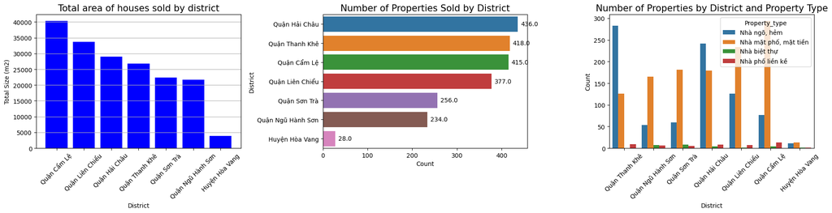

```python
fig, axes = plt.subplots(1, 3, figsize=(19, 5))

# Biểu đồ 1: Tổng diện tích các căn nhà bán theo quận
average_size_by_district = df1.groupby('District')['Size'].sum().sort_values(ascending=False)
axes[0].bar(average_size_by_district.index, average_size_by_district.values, color='blue')
axes[0].set_title('Total area of houses sold by district', fontsize=15)
axes[0].set_xlabel('District')
axes[0].set_ylabel('Total Size (m2)')
axes[0].tick_params(axis='x', rotation=45)
axes[0].grid(axis='y')
# Biểu đồ 2: Số lượng bất động sản được bán theo quận
sns.countplot(data=df1, y="District", order=df1["District"].value_counts().index, ax=axes[1])
for p in axes[1].patches:
    axes[1].annotate(f"{p.get_width()}", (p.get_width(), p.get_y() + p.get_height()/2.), ha="left", va="center", xytext=(5, 0), textcoords="offset points")
axes[1].set_title('Number of Properties Sold by District', fontsize=15)
axes[1].set_xlabel('Count')
axes[1].set_ylabel('District')

# Biểu đồ 3: Số lượng bất động sản theo loại bất động sản và quận
sns.countplot(data=df1, x="District", hue="Property_type", ax=axes[2])
axes[2].set_xticklabels(axes[2].get_xticklabels(), rotation=45)
axes[2].set_title('Number of Properties by District and Property Type', fontsize=15)
axes[2].set_xlabel('District')
axes[2].set_ylabel('Count')

# Hiển thị biểu đồ
plt.tight_layout()
plt.show()
```

- Quận Cẩm lệ có Diện tích nhà ở được rao bán cao nhất
- Quận Hải Châu lại có số nhà ở được rao bán cao nhất theo sau là quận Thanh Khê
- Đối với biểu đồ thứ 3 cho thấy ở quận Thanh Khê đang có nhu cầu rao bán các căn nhà loại Ngõ hẻm và quận Cẩm Lệ là Nhà mặt phố, mặt tiền đứng đầu trong các quận

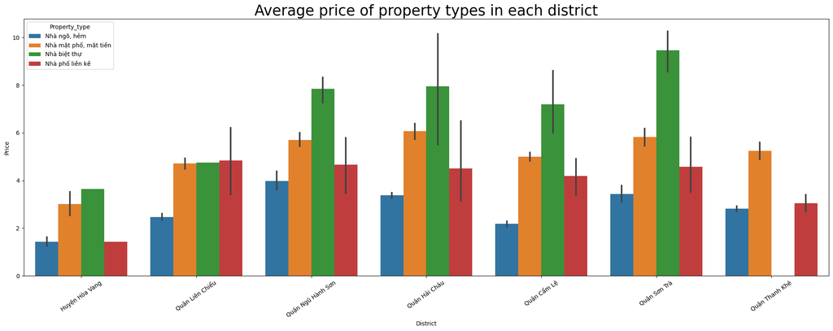

```python
plt.figure(figsize=(20, 8))
plt.title("Average price of property types in each district", fontsize=25)
sns.barplot(df1, x="District", y="Price", hue="Property_type", order=df.groupby("District")["Price"].mean().sort_values(ascending=False).index)
plt.xticks(rotation=35)
plt.tight_layout()
plt.show()
```

Cột Distance là khoảng cách các khối tài sản đến trung tâm thành phố (Trung tâm thành phố ở đây được chọn vị trí tại Trung tâm Hành chính Thành phố Đà Nẵng)

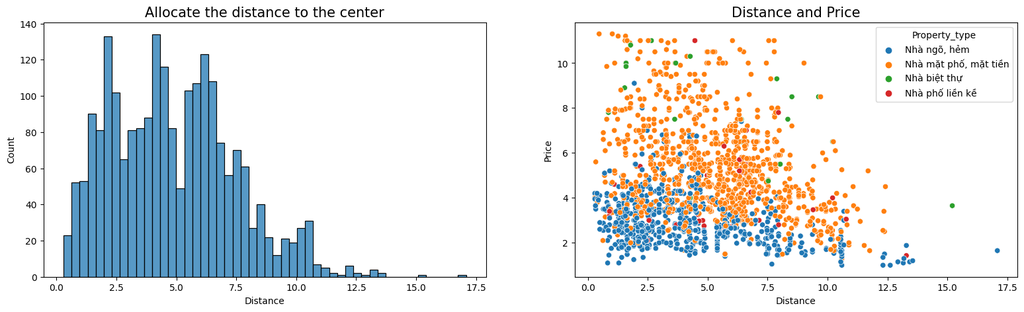

```python
fig, axes = plt.subplots(1, 2, figsize=(19, 5))

sns.histplot(df1, x="Distance", bins=50, ax=axes[0])
sns.scatterplot(df1, x="Distance", y="Price", hue="Property_type", ax=axes[1])

axes[0].set_title('Allocate the distance to the center', fontsize=15)
axes[1].set_title('Distance and Price', fontsize=15)
```

Nhìn chung giá nhà có xu hướng tằng khi khoảng cách đến trung tâm càng ngắn

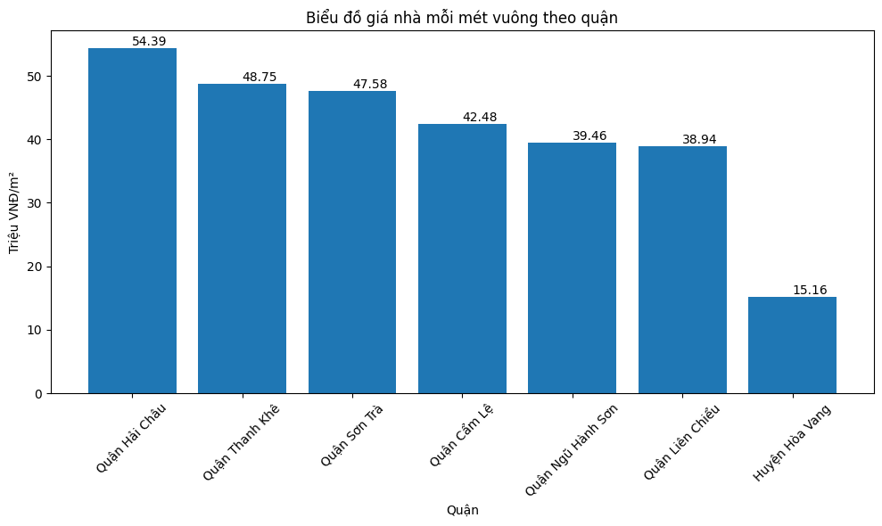

```python
average_price_per_sqm_by_district_sorted = (df1.groupby('District')['Price'].sum() / df.groupby('District')['Size'].sum() * 1000).sort_values(ascending=False)

plt.figure(figsize=(10, 6))
bars = plt.bar(average_price_per_sqm_by_district_sorted.index, average_price_per_sqm_by_district_sorted.values)

plt.xlabel('Quận')
plt.ylabel('Triệu VNĐ/m²')
plt.title('Biểu đồ giá nhà mỗi mét vuông theo quận')

for bar in bars:
    yval = bar.get_height()
    plt.text(bar.get_x() + bar.get_width()/2, yval, round(yval, 2), va='bottom')

plt.xticks(rotation=45)
plt.tight_layout()
plt.show()
```